# Cyclistic Data Wrangling Process

Renaldas Zlatkus

```r
getwd()
```

```
## [1] "C:/Users/renal/OneDrive/Bureaublad/Cyclistic"
```

# Introduction

Cyclistic is a fictional bike-sharing company based in Chicago and maintains 5,800 GPS-tracked bicycles spread over 600 docking stations. Cyclistic offers traditional bikes but also sets itself apart by offering reclining bikes, hand tricycles, and cargo bikes, allowing for more inclusivity to those with disabilities or riders who can’t use a traditional two-wheeled bike.

# Business Task

The business task provided by the director of Marketing, Lily Moreno, is the following question to be answered: “How do annual members and casual riders use Cyclistic bikes differently?”.

By answering this question Cyclistic will come closer in understanding its bike users and design effective marketing strategies aimed at converting casual riders into annual members. But before this can be answered the data needs to be cleaned, this is the cleaning process for it.

# Stakeholders

- Cyclistic Executive Team
- Director of Marketing (Lily Moreno)
- Marketing Analytics Team.

# Data preparation

The data to be analysed is made available by Motivation International Inc., under this [license](https://www.divvybikes.com/data-license-agreement), and can be downloaded from [here](https://divvy-tripdata.s3.amazonaws.com/index.html), or via the code bellow.  
To answer the question, “How do annual members and casual riders use Cyclistic bikes differently?”, provided in the business task I will be using and cleaning data collected between 1st of September 2020 and 31st of August 2021 and will be stored locally on my device.

```r
zip_location <- getwd()

download.file("https://divvy-tripdata.s3.amazonaws.com/202009-divvy-tripdata.zip", paste("zip_location", "202009-divvy-tripdata.zip"))
download.file("https://divvy-tripdata.s3.amazonaws.com/202010-divvy-tripdata.zip", paste("zip_location", "202010-divvy-tripdata.zip"))
download.file("https://divvy-tripdata.s3.amazonaws.com/202011-divvy-tripdata.zip", paste("zip_location", "202011-divvy-tripdata.zip"))
download.file("https://divvy-tripdata.s3.amazonaws.com/202012-divvy-tripdata.zip", paste("zip_location", "202012-divvy-tripdata.zip"))
download.file("https://divvy-tripdata.s3.amazonaws.com/202101-divvy-tripdata.zip", paste("zip_location", "202101-divvy-tripdata.zip"))
download.file("https://divvy-tripdata.s3.amazonaws.com/202102-divvy-tripdata.zip", paste("zip_location", "202102-divvy-tripdata.zip"))
download.file("https://divvy-tripdata.s3.amazonaws.com/202103-divvy-tripdata.zip", paste("zip_location", "202103-divvy-tripdata.zip"))
download.file("https://divvy-tripdata.s3.amazonaws.com/202104-divvy-tripdata.zip", paste("zip_location", "202104-divvy-tripdata.zip"))
download.file("https://divvy-tripdata.s3.amazonaws.com/202105-divvy-tripdata.zip", paste("zip_location", "202105-divvy-tripdata.zip"))
download.file("https://divvy-tripdata.s3.amazonaws.com/202106-divvy-tripdata.zip", paste("zip_location", "202106-divvy-tripdata.zip"))
download.file("https://divvy-tripdata.s3.amazonaws.com/202107-divvy-tripdata.zip", paste("zip_location", "202107-divvy-tripdata.zip"))
download.file("https://divvy-tripdata.s3.amazonaws.com/202108-divvy-tripdata.zip", paste("zip_location", "202108-divvy-tripdata.zip"))
```

# Data Integrity

Although Cyclistic is a fictional company the data is provided by Divvy Bikes. Divvy Bikes is a program of the Chicago Department of Transportation (CDOT) and Lyft, Inc. is currently managing this bike sharing system in the United States. Henceforth, the data used for this analysis comes from a first party data provider and to the best of my knowledge can be considered as highly reliable.

# Tools

For this analysis I will be using R (version 4.1.2), which is a programming language for statistical computing and graphics. Furthermore, in R I will make use of several libraries to perform data cleaning, see the list below.

```r
#Set working directory to where you want to save the data via setwd(~your path), or Session -> Set Working Directory -> Choose Directory.

#Install packages required packages for this process.

#install.packages("tidyverse")
#install.packages("data.table")
#install.packages("plyr")
#install.packages("DataExplorer")
#install.packages("lubridate")
#install.packages("janitor")
#install.packages("tidygeocoder")
#install.packages("rnoaa")
#install.packages("weathermetrics")

#Load library.

library(tidyverse)
library(plyr)
library(data.table)
library(DataExplorer)
library(lubridate)
library(janitor)
library(tidygeocoder)
library(rnoaa)
library(weathermetrics)
```

# About the data

The data consist of 12 separate comma-separated value (CSV) files with “,” as the delimiter, it has 13 variables with 4.913.072 rows and a size on disk of 870 MB:

- ride_id
- rideable_type
- started_at
- ended_at
- start_station_name
- start_station_id
- end_station_name
- end_station_id
- start_lat
- start_lng
- end_lat
- end_lng
- member_casual

```r
#Extracting all csv files from the zip files saved in your Working directory.

my_dir <- getwd()
zip_file <- list.files(path = my_dir, pattern = "*.zip",
                       full.names = TRUE)

ldply(.data = zip_file, .fun = unzip, exdir = my_dir)
```

```
##                                                                        V1
## 1  C:/Users/renal/OneDrive/Bureaublad/Cyclistic/202009-divvy-tripdata.csv
## 2  C:/Users/renal/OneDrive/Bureaublad/Cyclistic/202010-divvy-tripdata.csv
## 3  C:/Users/renal/OneDrive/Bureaublad/Cyclistic/202011-divvy-tripdata.csv
## 4  C:/Users/renal/OneDrive/Bureaublad/Cyclistic/202012-divvy-tripdata.csv
## 5  C:/Users/renal/OneDrive/Bureaublad/Cyclistic/202101-divvy-tripdata.csv
## 6  C:/Users/renal/OneDrive/Bureaublad/Cyclistic/202102-divvy-tripdata.csv
## 7  C:/Users/renal/OneDrive/Bureaublad/Cyclistic/202103-divvy-tripdata.csv
## 8  C:/Users/renal/OneDrive/Bureaublad/Cyclistic/202104-divvy-tripdata.csv
## 9  C:/Users/renal/OneDrive/Bureaublad/Cyclistic/202105-divvy-tripdata.csv
## 10 C:/Users/renal/OneDrive/Bureaublad/Cyclistic/202106-divvy-tripdata.csv
## 11 C:/Users/renal/OneDrive/Bureaublad/Cyclistic/202107-divvy-tripdata.csv
## 12 C:/Users/renal/OneDrive/Bureaublad/Cyclistic/202108-divvy-tripdata.csv
##                                                                                   V2
## 1  C:/Users/renal/OneDrive/Bureaublad/Cyclistic/__MACOSX/._202009-divvy-tripdata.csv
## 2  C:/Users/renal/OneDrive/Bureaublad/Cyclistic/__MACOSX/._202010-divvy-tripdata.csv
## 3  C:/Users/renal/OneDrive/Bureaublad/Cyclistic/__MACOSX/._202011-divvy-tripdata.csv
## 4  C:/Users/renal/OneDrive/Bureaublad/Cyclistic/__MACOSX/._202012-divvy-tripdata.csv
## 5  C:/Users/renal/OneDrive/Bureaublad/Cyclistic/__MACOSX/._202101-divvy-tripdata.csv
## 6  C:/Users/renal/OneDrive/Bureaublad/Cyclistic/__MACOSX/._202102-divvy-tripdata.csv
## 7  C:/Users/renal/OneDrive/Bureaublad/Cyclistic/__MACOSX/._202103-divvy-tripdata.csv
## 8  C:/Users/renal/OneDrive/Bureaublad/Cyclistic/__MACOSX/._202104-divvy-tripdata.csv
## 9  C:/Users/renal/OneDrive/Bureaublad/Cyclistic/__MACOSX/._202105-divvy-tripdata.csv
## 10 C:/Users/renal/OneDrive/Bureaublad/Cyclistic/__MACOSX/._202106-divvy-tripdata.csv
## 11 C:/Users/renal/OneDrive/Bureaublad/Cyclistic/__MACOSX/._202107-divvy-tripdata.csv
## 12 C:/Users/renal/OneDrive/Bureaublad/Cyclistic/__MACOSX/._202108-divvy-tripdata.csv
```

```r
#Load extracted csv files into one data.table.

dataset <- ldply(list.files(path = my_dir, pattern = "*.csv", full.names = TRUE), fread, header=T, na.string = c("", "NA"))

#Investigate data table.

colnames(dataset)
```

```
##  [1] "ride_id"            "rideable_type"      "started_at"
##  [4] "ended_at"           "start_station_name" "start_station_id"
##  [7] "end_station_name"   "end_station_id"     "start_lat"
## [10] "start_lng"          "end_lat"            "end_lng"
## [13] "member_casual"
```

```r
#Number of rows and variables.
dim(dataset)
```

```
## [1] 4913072      13
```

```r
#------------------------------Rename column names.

setnames(dataset, old =  c("rideable_type", "start_station_name", "end_station_name", "member_casual"),
         new = c("bike_type", "start_station", "end_station", "user_type"))

colnames(dataset)
```

```
##  [1] "ride_id"          "bike_type"        "started_at"       "ended_at"
##  [5] "start_station"    "start_station_id" "end_station"      "end_station_id"
##  [9] "start_lat"        "start_lng"        "end_lat"          "end_lng"
## [13] "user_type"
```

```r
##Remove "_bike" from column rideable_type.

str(dataset)
```

```
## 'data.frame':    4913072 obs. of  13 variables:
##  $ ride_id         : chr  "2B22BD5F95FB2629" "A7FB70B4AFC6CAF2" "86057FA01BAC778E" "57F6DC9A153DB98C" ...
##  $ bike_type       : chr  "electric_bike" "electric_bike" "electric_bike" "electric_bike" ...
##  $ started_at      : POSIXct, format: "2020-09-17 14:27:11" "2020-09-17 15:07:31" ...
##  $ ended_at        : POSIXct, format: "2020-09-17 14:44:24" "2020-09-17 15:07:45" ...
##  $ start_station   : chr  "Michigan Ave & Lake St" "W Oakdale Ave & N Broadway" "W Oakdale Ave & N Broadway" "Ashland Ave & Belle Plaine Ave" ...
##  $ start_station_id: chr  "52" NA NA "246" ...
##  $ end_station     : chr  "Green St & Randolph St" "W Oakdale Ave & N Broadway" "W Oakdale Ave & N Broadway" "Montrose Harbor" ...
##  $ end_station_id  : chr  "112" NA NA "249" ...
##  $ start_lat       : num  41.9 41.9 41.9 42 41.9 ...
##  $ start_lng       : num  -87.6 -87.6 -87.6 -87.7 -87.6 ...
##  $ end_lat         : num  41.9 41.9 41.9 42 41.9 ...
##  $ end_lng         : num  -87.6 -87.6 -87.6 -87.6 -87.6 ...
##  $ user_type       : chr  "casual" "casual" "casual" "casual" ...
```

```r
dataset <- dataset %>%
  mutate_at("bike_type", str_replace, "_bike", "")

str(dataset)
```

```
## 'data.frame':    4913072 obs. of  13 variables:
##  $ ride_id         : chr  "2B22BD5F95FB2629" "A7FB70B4AFC6CAF2" "86057FA01BAC778E" "57F6DC9A153DB98C" ...
##  $ bike_type       : chr  "electric" "electric" "electric" "electric" ...
##  $ started_at      : POSIXct, format: "2020-09-17 14:27:11" "2020-09-17 15:07:31" ...
##  $ ended_at        : POSIXct, format: "2020-09-17 14:44:24" "2020-09-17 15:07:45" ...
##  $ start_station   : chr  "Michigan Ave & Lake St" "W Oakdale Ave & N Broadway" "W Oakdale Ave & N Broadway" "Ashland Ave & Belle Plaine Ave" ...
##  $ start_station_id: chr  "52" NA NA "246" ...
##  $ end_station     : chr  "Green St & Randolph St" "W Oakdale Ave & N Broadway" "W Oakdale Ave & N Broadway" "Montrose Harbor" ...
##  $ end_station_id  : chr  "112" NA NA "249" ...
##  $ start_lat       : num  41.9 41.9 41.9 42 41.9 ...
##  $ start_lng       : num  -87.6 -87.6 -87.6 -87.7 -87.6 ...
##  $ end_lat         : num  41.9 41.9 41.9 42 41.9 ...
##  $ end_lng         : num  -87.6 -87.6 -87.6 -87.6 -87.6 ...
##  $ user_type       : chr  "casual" "casual" "casual" "casual" ...
```

```r
gc()
```

```
##             used  (Mb) gc trigger   (Mb)  max used   (Mb)
## Ncells   6221082 332.3    9423298  503.3   6456181  344.8
## Vcells 108542823 828.2  198621917 1515.4 198542624 1514.8
```

```r
#Check unique strings in start_station_name and end_station_name.
#We can see in row 659 "HIBBARD ST BIKE CHECKING (LBS-WH-TEST)", 707 "WEST CHI-WATSON", 726 ("DIVVY CASSETTE REPAIR MOBILE STATION"), 747 the number "351".
#These will be investigate more, but they seem not to fit in.

uniq_street_name <- data.frame(unique(dataset$start_station))
View(uniq_street_name)
View(c(uniq_street_name[707,], uniq_street_name[726,], uniq_street_name[747,]))

#Checking for rows with only uppercase characters
upper_case <- dataset %>%
  filter(str_detect(start_station, '[:upper:]') & !str_detect(start_station, '[:lower:]'))

#Viewing upper_case confirms my suspicion that these are no regular user rides and thus can be deleted.
View(upper_case)

#Start_station_id instead of start_station_name
check_1 <- dataset %>%
  filter(nchar(start_station) < 4)

#start_station_id 351 is Cottage Grove Ave & 51st St
dataset$start_station[dataset$start_station == "351"] <- "Cottage Grove Ave & 51st St"

#DiVVY has 1424 observation that match in start_station.
check_2 <- dataset[dataset$start_station %like% "DIVVY", ]
#Delete 1424 rows containing "DIVVY".
dataset <- dataset[!grepl("DIVVY",dataset$start_station),]

#TEST has 47 observation that match in start_station.
check_3 <- dataset[dataset$start_station %like% "TEST", ]
#Delete 47 rows containing "TEST".
dataset <- dataset[!grepl("TEST",dataset$start_station),]

#WATSON has 83 observation that match in start_station.
check_4 <- dataset[dataset$start_station %like% "WATSON", ]
#Delete 83 rows containing "WATSON".
dataset <- dataset[!grepl("WATSON",dataset$start_station),]

#DIVVY has 4 observation that match in end_station.
check_5 <- dataset[dataset$end_station %like% "DIVVY", ]
#Delete 4 rows containing "Divvy".
dataset <- dataset[!grepl("DIVVY",dataset$end_station),]

#TEST has 141 observation that match in end_station.
check_6 <- dataset[dataset$end_station %like% "TEST", ]
#Delete 141 row containing "TEST".
dataset <- dataset[!grepl("TEST",dataset$end_station),]

#WATSON has 0 observations that match in end_station.
check_7 <- dataset[dataset$end_station %like% "WATSON", ]

upper_case <- dataset %>%
  filter(str_detect(start_station, '[:upper:]') & !str_detect(start_station, '[:lower:]'))

rm(check_1, check_2, check_3, check_4, check_5, check_6, check_7, upper_case, uniq_street_name)

gc()
```

```
##             used  (Mb) gc trigger   (Mb)  max used   (Mb)
## Ncells   6227658 332.6    9423298  503.3   6456181  344.8
## Vcells 110994143 846.9  238426300 1819.1 237325673 1810.7
```

```r
#Further familiarization with the data.

head(dataset)
```

```
##            ride_id bike_type          started_at            ended_at
## 1 2B22BD5F95FB2629  electric 2020-09-17 14:27:11 2020-09-17 14:44:24
## 2 A7FB70B4AFC6CAF2  electric 2020-09-17 15:07:31 2020-09-17 15:07:45
## 3 86057FA01BAC778E  electric 2020-09-17 15:09:04 2020-09-17 15:09:35
## 4 57F6DC9A153DB98C  electric 2020-09-17 18:10:46 2020-09-17 18:35:49
## 5 B9C4712F78C1AE68  electric 2020-09-17 15:16:13 2020-09-17 15:52:55
## 6 378BBCE1E444EB80  electric 2020-09-17 18:37:04 2020-09-17 19:23:28
##                    start_station start_station_id                end_station
## 1         Michigan Ave & Lake St               52     Green St & Randolph St
## 2     W Oakdale Ave & N Broadway             <NA> W Oakdale Ave & N Broadway
## 3     W Oakdale Ave & N Broadway             <NA> W Oakdale Ave & N Broadway
## 4 Ashland Ave & Belle Plaine Ave              246            Montrose Harbor
## 5       Fairbanks Ct & Grand Ave               24   Fairbanks Ct & Grand Ave
## 6        Clark St & Armitage Ave               94                       <NA>
##   end_station_id start_lat start_lng  end_lat   end_lng user_type
## 1            112  41.88669 -87.62356 41.88357 -87.64873    casual
## 2           <NA>  41.94000 -87.64000 41.94000 -87.64000    casual
## 3           <NA>  41.94000 -87.64000 41.94000 -87.64000    casual
## 4            249  41.95606 -87.66892 41.96398 -87.63822    casual
## 5             24  41.89186 -87.62101 41.89135 -87.62032    casual
## 6           <NA>  41.91826 -87.63636 41.88000 -87.62000    casual
```

```r
tail(dataset)
```

```
##                  ride_id bike_type          started_at            ended_at
## 4913067 2D6861BE1B6741CF   classic 2021-08-07 10:52:09 2021-08-07 10:58:09
## 4913068 5E5C9CD681E0419C   classic 2021-08-07 18:07:43 2021-08-07 18:21:21
## 4913069 96FB57CF4AA456F6  electric 2021-08-09 08:49:31 2021-08-09 09:03:51
## 4913070 226A0910DCCE904C   classic 2021-08-12 16:55:57 2021-08-12 17:15:10
## 4913071 1A97D27AE23DE1E7   classic 2021-08-08 22:47:43 2021-08-08 23:08:12
## 4913072 BBC36E4AA3652361  electric 2021-08-27 18:53:53 2021-08-27 19:02:16
##                    start_station start_station_id                 end_station
## 4913067  Paulina Ave & North Ave     TA1305000037      Leavitt St & North Ave
## 4913068 Wells St & Evergreen Ave     TA1308000049 Lincoln Ave & Diversey Pkwy
## 4913069   Broadway & Sheridan Rd            13323      Clark St & Lincoln Ave
## 4913070   Dearborn St & Adams St     TA1305000005      Clark St & Lincoln Ave
## 4913071   Broadway & Sheridan Rd            13323     Clark St & Winnemac Ave
## 4913072  Paulina Ave & North Ave     TA1305000037       Dayton St & North Ave
##         end_station_id start_lat start_lng  end_lat   end_lng user_type
## 4913067   TA1308000005  41.90985 -87.66993 41.91051 -87.68239    member
## 4913068   TA1307000064  41.90672 -87.63483 41.93223 -87.65862    member
## 4913069          13179  41.95271 -87.64994 41.91597 -87.63476    member
## 4913070          13179  41.87936 -87.62979 41.91569 -87.63460    member
## 4913071   TA1309000035  41.95283 -87.64999 41.97335 -87.66786    casual
## 4913072          13058  41.90985 -87.66981 41.91067 -87.64955    casual
```

```r
glimpse(dataset)
```

```
## Rows: 4,911,373
## Columns: 13
## $ ride_id          <chr> "2B22BD5F95FB2629", "A7FB70B4AFC6CAF2", "86057FA01BAC~
## $ bike_type        <chr> "electric", "electric", "electric", "electric", "elec~
## $ started_at       <dttm> 2020-09-17 14:27:11, 2020-09-17 15:07:31, 2020-09-17~
## $ ended_at         <dttm> 2020-09-17 14:44:24, 2020-09-17 15:07:45, 2020-09-17~
## $ start_station    <chr> "Michigan Ave & Lake St", "W Oakdale Ave & N Broadway~
## $ start_station_id <chr> "52", NA, NA, "246", "24", "94", "291", NA, NA, NA, "~
## $ end_station      <chr> "Green St & Randolph St", "W Oakdale Ave & N Broadway~
## $ end_station_id   <chr> "112", NA, NA, "249", "24", NA, "256", NA, NA, NA, "2~
## $ start_lat        <dbl> 41.88669, 41.94000, 41.94000, 41.95606, 41.89186, 41.~
## $ start_lng        <dbl> -87.62356, -87.64000, -87.64000, -87.66892, -87.62101~
## $ end_lat          <dbl> 41.88357, 41.94000, 41.94000, 41.96398, 41.89135, 41.~
## $ end_lng          <dbl> -87.64873, -87.64000, -87.64000, -87.63822, -87.62032~
## $ user_type        <chr> "casual", "casual", "casual", "casual", "casual", "ca~
```

```r
summary(dataset)
```

```
##    ride_id           bike_type           started_at
##  Length:4911373     Length:4911373     Min.   :2020-09-01 00:00:07
##  Class :character   Class :character   1st Qu.:2020-12-10 06:30:45
##  Mode  :character   Mode  :character   Median :2021-05-26 17:11:36
##                                        Mean   :2021-04-11 07:55:20
##                                        3rd Qu.:2021-07-17 06:16:06
##                                        Max.   :2021-08-31 23:59:35
##
##     ended_at                   start_station      start_station_id
##  Min.   :2020-09-01 00:04:43   Length:4911373     Length:4911373
##  1st Qu.:2020-12-09 22:31:28   Class :character   Class :character
##  Median :2021-05-26 17:31:51   Mode  :character   Mode  :character
##  Mean   :2021-04-11 08:16:23
##  3rd Qu.:2021-07-17 06:55:08
##  Max.   :2021-09-01 17:37:35
##
##  end_station        end_station_id       start_lat       start_lng
##  Length:4911373     Length:4911373     Min.   :41.64   Min.   :-87.84
##  Class :character   Class :character   1st Qu.:41.88   1st Qu.:-87.66
##  Mode  :character   Mode  :character   Median :41.90   Median :-87.64
##                                        Mean   :41.90   Mean   :-87.65
##                                        3rd Qu.:41.93   3rd Qu.:-87.63
##                                        Max.   :42.08   Max.   :-87.52
##
##     end_lat         end_lng        user_type
##  Min.   :41.51   Min.   :-88.07   Length:4911373
##  1st Qu.:41.88   1st Qu.:-87.66   Class :character
##  Median :41.90   Median :-87.64   Mode  :character
##  Mean   :41.90   Mean   :-87.64
##  3rd Qu.:41.93   3rd Qu.:-87.63
##  Max.   :42.15   Max.   :-87.44
##  NA's   :5015    NA's   :5015
```

```r
#Double check data type of each column.

is.character(dataset$ride_id)
```

```
## [1] TRUE
```

```r
is.character(dataset$bike_type)
```

```
## [1] TRUE
```

```r
is.POSIXct(dataset$started_at)
```

```
## [1] TRUE
```

```r
is.POSIXct(dataset$ended_at)
```

```
## [1] TRUE
```

```r
is.character(dataset$start_station)
```

```
## [1] TRUE
```

```r
is.character(dataset$start_station_id)
```

```
## [1] TRUE
```

```r
is.character(dataset$end_station)
```

```
## [1] TRUE
```

```r
is.character(dataset$end_station_id)
```

```
## [1] TRUE
```

```r
is.numeric(dataset$start_lat)
```

```
## [1] TRUE
```

```r
is.numeric(dataset$start_lng)
```

```
## [1] TRUE
```

```r
is.numeric(dataset$end_lat)
```

```
## [1] TRUE
```

```r
is.numeric(dataset$end_lng)
```

```
## [1] TRUE
```

```r
is.character(dataset$user_type)
```

```
## [1] TRUE
```

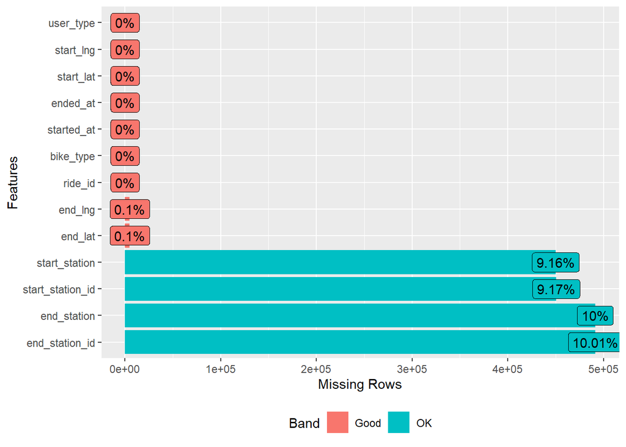

```r
#Check for NA's
# 6 columns appear to have missing values and most be addressed.
plot_missing(dataset)
```

```r
check_9 <- dataset %>%
  filter(is.na(start_station))

check_10 <- dataset %>%
  filter(is.na(end_station))
```

```r
#Data enrichment, find streets through latitude and longitude data.
#Tidygeocoder is a newly published R package which provides a tidyverse-style interface for geocoding.
#It returns latitude and longitude coordinates in tibble format from addresses using the US Census or Nominatim (OSM) geocoder services.
#However this will take approximately 30 min to complete.

enriched_start_station <- check_9 %>%
  reverse_geocode(lat = start_lat, long = start_lng, method = "osm",
                  full_results = TRUE) %>%
  select(ride_id, address, road)
```

```
## Passing 678 coordinates to the Nominatim single coordinate geocoder
```

```
## Query completed in: 701 seconds
```

```r
enriched_end_station <- check_10 %>%
  reverse_geocode(lat = end_lat, long = end_lng, method = "osm",
                  full_results = TRUE) %>%
  select(ride_id, address, road)
```

```
## Passing 839 coordinates to the Nominatim single coordinate geocoder
```

```
## Query completed in: 868.9 seconds
```

```r
rm(check_9, check_10)
gc()
```

```
##             used  (Mb) gc trigger   (Mb)  max used   (Mb)
## Ncells   6426346 343.3   14368564  767.4  14368564  767.4
## Vcells 114251506 871.7  288566058 2201.6 288468860 2200.9
```

```r
#Combine road column with A (address) into one column.

enriched_start <- as.data.table(enriched_start_station) %>%
  separate(address, c("A", "B", ",")) %>%
  mutate(start_station = coalesce(road, A)) %>%
  select(c(ride_id, start_station))
enriched_end <- as.data.table(enriched_end_station) %>%
  separate(address, c("A", "B", ",")) %>%
  mutate(end_station = coalesce(road, A)) %>%
  select(c(ride_id, end_station))
rm(enriched_start_station, enriched_end_station)
```

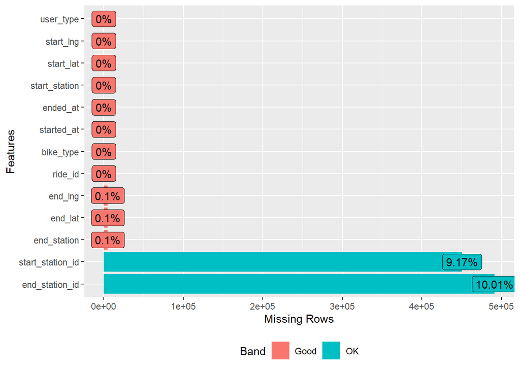

```r
#Merge data set with the enriched data.

dataset <- as.data.table(dataset)

setkey(dataset, ride_id)
setkey(enriched_start, ride_id)
setkey(enriched_end, ride_id)

merge1 <- merge.data.table(dataset, enriched_start, all = TRUE)
merge2 <- merge.data.table(merge1, enriched_end, all = TRUE)

dataset <- merge2 %>%
  mutate(start_station = coalesce(start_station.x, start_station.y)) %>%
  mutate(end_station = coalesce(end_station.x, end_station.y)) %>%
  select(-c(start_station.x, end_station.x, start_station.y, end_station.y)) %>%
  relocate(start_station, .after = ended_at) %>%
  relocate(end_station, .after = start_station_id)

#NA data is significantly reduced. However, end_lng, end_lat, and end_station still have 0.1% missing but will
#not be deleted because it will have no effect on the analysis later.
plot_missing(dataset)
```

```r
remove(enriched_end, enriched_start, merge1, merge2)
gc()
```

```
##             used  (Mb) gc trigger   (Mb)  max used   (Mb)
## Ncells   6465766 345.4   14368564  767.4  14368564  767.4
## Vcells 109093048 832.4  332990312 2540.6 365467909 2788.3
```

```r
#Data enrichment from National Oceanic and Atmospheric Administration using their r-package (rnoaa)

weather_stations <- ghcnd_stations()
```

```
## using cached file: C:\Users\renal\AppData\Local/Cache/R/noaa_ghcnd/ghcnd-stations.rds
```

```
## date created (size, mb): 2022-01-09 18:22:50 (2.159)
```

```
## using cached file: C:\Users\renal\AppData\Local/Cache/R/noaa_ghcnd/ghcnd-inventory.rds
```

```
## date created (size, mb): 2022-01-09 18:24:48 (2.653)
```

```r
#Chicago  latitude and longitude data frame.

id = "chicago"
latitude <- as.numeric("41.881832")
longitude <- as.numeric("-87.623177")
lat_lon_df <- data.frame(id, latitude, longitude)

#Locate a weather stations that records all possible weather variables and has records of 2020 and 2021.

lcd_weather_stations <- meteo_distance(weather_stations, lat_lon_df$latitude, lat_lon_df$longitude, radius = 25, limit = NULL)
isd_weather_stations <- isd_stations_search(lat = lat_lon_df$latitude, lon = lat_lon_df$longitude, radius = 25)
```

```
## using cached file: C:\Users\renal\AppData\Local\cache\R\noaa_isd\isd_stations.rds
```

```
## date created (size, mb): 2022-01-16 17:26:22 (0.682)
```

```r
str(lcd_weather_stations)
```

```
## tibble [611 x 12] (S3: tbl_df/tbl/data.frame)
##  $ id        : chr [1:611] "US1ILCK0036" "US1ILCK0036" "US1ILCK0036" "US1ILCK0036" ...
##  $ latitude  : num [1:611] 41.9 41.9 41.9 41.9 41.9 ...
##  $ longitude : num [1:611] -87.6 -87.6 -87.6 -87.6 -87.6 ...
##  $ elevation : num [1:611] 191 191 191 191 183 ...
##  $ state     : chr [1:611] "IL" "IL" "IL" "IL" ...
##  $ name      : chr [1:611] "CHICAGO 4.7 NE" "CHICAGO 4.7 NE" "CHICAGO 4.7 NE" "CHICAGO 4.7 NE" ...
##  $ gsn_flag  : chr [1:611] "" "" "" "" ...
##  $ wmo_id    : chr [1:611] "" "" "" "" ...
##  $ element   : chr [1:611] "PRCP" "SNOW" "DAPR" "MDPR" ...
##  $ first_year: int [1:611] 2007 2007 2007 2007 1972 1972 1901 1901 1964 1836 ...
##  $ last_year : int [1:611] 2020 2020 2020 2020 1976 1976 1965 1965 1964 1965 ...
##  $ distance  : num [1:611] 0.497 0.497 0.497 0.497 0.561 ...
```

```r
str(isd_weather_stations)
```

```
## tibble [14 x 12] (S3: tbl_df/tbl/data.frame)
##  $ usaf        : chr [1:14] "999999" "725346" "725346" "998499" ...
##  $ wban        : chr [1:14] "94866" "94866" "99999" "99999" ...
##  $ station_name: chr [1:14] "CHICAGO MEIGS FIELD" "CHICAGO/MEIGS" "CHICAGO/MEIGS" "NORTHERLY ISLAND" ...
##  $ ctry        : chr [1:14] "US" "US" "US" "US" ...
##  $ state       : chr [1:14] "IL" "IL" "IL" "IL" ...
##  $ icao        : chr [1:14] "CGX" "KCGX" "KCGX" "" ...
##  $ lat         : num [1:14] 41.9 41.9 41.9 41.9 42 ...
##  $ lon         : num [1:14] -87.6 -87.6 -87.6 -87.6 -87.6 ...
##  $ elev_m      : num [1:14] 180 181 181 190 177 ...
##  $ begin       : num [1:14] 19660101 19730101 20000101 20120618 20120620 ...
##  $ end         : num [1:14] 19700701 20080618 20030409 20220113 20201125 ...
##  $ distance    : num [1:14] 1.73 2.53 2.53 3.1 10.67 ...
```

```r
#Chicago Midway Airport seems to meet all the criteria.

isd_2020 <- isd_weather_stations %>%
  filter(end > 20200101)

lcd_2020 <- lcd_weather_stations %>%
  filter(last_year > 2020)


#Select all variables and then determine which to use.

columns <- lcd_columns(STATION = "character",
                       DATE = "POSIXct",
                       LATITUDE = "numeric",
                       LONGITUDE = "numeric",
                       ELEVATION = "numeric",
                       NAME = "character",
                       REPORT_TYPE = "character",
                       SOURCE = "character",
                       HourlyAltimeterSetting = "character",
                       HourlyDewPointTemperature = "character",
                       HourlyDryBulbTemperature = "character",
                       HourlyPrecipitation = "character",
                       HourlyPresentWeatherType = "character",
                       HourlyPressureChange = "character",
                       HourlyPressureTendency = "integer",
                       HourlyRelativeHumidity = "character",
                       HourlySkyConditions = "character",
                       HourlySeaLevelPressure = "character",
                       HourlyStationPressure = "character",
                       HourlyVisibility = "character",
                       HourlyWetBulbTemperature = "character",
                       HourlyWindDirection = "character",
                       HourlyWindGustSpeed = "character",
                       HourlyWindSpeed = "character",
                       Sunrise = "numeric",
                       Sunset = "numeric",
                       DailyAverageDewPointTemperature = "character",
                       DailyAverageDryBulbTemperature = "character",
                       DailyAverageRelativeHumidity = "character",
                       DailyAverageSeaLevelPressure = "character",
                       DailyAverageStationPressure = "character",
                       DailyAverageWetBulbTemperature = "character",
                       DailyAverageWindSpeed = "character",
                       DailyCoolingDegreeDays = "numeric",
                       DailyDepartureFromNormalAverageTemperature = "numeric",
                       DailyHeatingDegreeDays = "numeric",
                       DailyMaximumDryBulbTemperature = "numeric",
                       DailyMinimumDryBulbTemperature = "numeric",
                       DailyPeakWindDirection = "numeric",
                       DailyPeakWindSpeed = "numeric",
                       DailyPrecipitation = "character",
                       DailySnowDepth = "character",
                       DailySnowfall = "character",
                       DailySustainedWindDirection = "numeric",
                       DailySustainedWindSpeed = "numeric",
                       DailyWeather = "character",
                       MonthlyAverageRH = "numeric",
                       MonthlyDaysWithGT001Precip = "character",
                       MonthlyDaysWithGT010Precip = "character",
                       MonthlyDaysWithGT32Temp = "numeric",
                       MonthlyDaysWithGT90Temp = "numeric",
                       MonthlyDaysWithLT0Temp = "numeric",
                       MonthlyDaysWithLT32Temp = "numeric",
                       MonthlyDepartureFromNormalAverageTemperature = "numeric",
                       MonthlyDepartureFromNormalCoolingDegreeDays = "numeric",
                       MonthlyDepartureFromNormalHeatingDegreeDays = "numeric",
                       MonthlyDepartureFromNormalMaximumTemperature = "numeric",
                       MonthlyDepartureFromNormalMinimumTemperature = "numeric",
                       MonthlyDepartureFromNormalPrecipitation = "numeric",
                       MonthlyDewpointTemperature = "numeric",
                       MonthlyGreatestPrecip = "character",
                       MonthlyGreatestPrecipDate = "character",
                       MonthlyGreatestSnowDepth = "numeric",
                       MonthlyGreatestSnowDepthDate = "character",
                       MonthlyGreatestSnowfall = "character",
                       MonthlyGreatestSnowfallDate = "character",
                       MonthlyMaxSeaLevelPressureValue = "numeric",
                       MonthlyMaxSeaLevelPressureValueDate = "character",
                       MonthlyMaxSeaLevelPressureValueTime = "character",
                       MonthlyMaximumTemperature = "numeric",
                       MonthlyMeanTemperature = "numeric",
                       MonthlyMinSeaLevelPressureValue = "numeric",
                       MonthlyMinSeaLevelPressureValueDate = "character",
                       MonthlyMinSeaLevelPressureValueTime = "character",
                       MonthlyMinimumTemperature = "numeric",
                       MonthlySeaLevelPressure = "numeric",
                       MonthlyStationPressure = "numeric",
                       MonthlyTotalLiquidPrecipitation = "character",
                       MonthlyTotalSnowfall = "character",
                       MonthlyWetBulb = "numeric",
                       AWND = "numeric",
                       CDSD = "numeric",
                       CLDD = "numeric",
                       DSNW = "numeric",
                       HDSD = "numeric",
                       HTDD = "numeric",
                       NormalsCoolingDegreeDay = "numeric",
                       NormalsHeatingDegreeDay = "numeric",
                       ShortDurationEndDate005 = "character",
                       ShortDurationEndDate010 = "character",
                       ShortDurationEndDate015 = "character",
                       ShortDurationEndDate020 = "character",
                       ShortDurationEndDate030 = "character",
                       ShortDurationEndDate045 = "character",
                       ShortDurationEndDate060 = "character",
                       ShortDurationEndDate080 = "character",
                       ShortDurationEndDate100 = "character",
                       ShortDurationEndDate120 = "character",
                       ShortDurationEndDate150 = "character",
                       ShortDurationEndDate180 = "character",
                       ShortDurationPrecipitationValue005 = "numeric",
                       ShortDurationPrecipitationValue010 = "numeric",
                       ShortDurationPrecipitationValue015 = "numeric",
                       ShortDurationPrecipitationValue020 = "numeric",
                       ShortDurationPrecipitationValue030 = "numeric",
                       ShortDurationPrecipitationValue045 = "numeric",
                       ShortDurationPrecipitationValue060 = "numeric",
                       ShortDurationPrecipitationValue080 = "numeric",
                       ShortDurationPrecipitationValue100 = "numeric",
                       ShortDurationPrecipitationValue120 = "numeric",
                       ShortDurationPrecipitationValue150 = "numeric",
                       ShortDurationPrecipitationValue180 = "numeric",
                       REM = "character",
                       BackupDirection = "character",
                       BackupDistance = "character",
                       BackupDistanceUnit = "character",
                       BackupElements = "character",
                       BackupElevation = "character",
                       BackupEquipment = "character",
                       BackupLatitude = "character",
                       BackupLongitude = "character",
                       BackupName = "character",
                       WindEquipmentChangeDate = "character")

#Combine USAF and WBAN numbers from isd_2020 to get the lcd station id.

chicago_midway <- "72534014819"

#Gather all weather data from 2020 and 2021.

midway_2020 <- data.frame(lcd(station = chicago_midway, year = 2020, col_types = columns))
```

```
## using cached file: C:\Users\renal\AppData\Local/Cache/R/noaa_lcd/2020_72534014819.csv
```

```
## date created (size, mb): 2022-01-10 22:46:40 (8.092)
```

```r
midway_2021 <- data.frame(lcd(station = chicago_midway, year = 2021, col_types = columns))
```

```
## using cached file: C:\Users\renal\AppData\Local/Cache/R/noaa_lcd/2021_72534014819.csv
```

```
## date created (size, mb): 2022-01-11 11:58:06 (7.997)
```

```r
#Merge data from 2020 and 2021 into one data frame.

midway_data <- merge(midway_2020, midway_2021, all = TRUE) %>%
  select(date, hourlydewpointtemperature, hourlydrybulbtemperature, hourlyprecipitation,
         hourlyrelativehumidity, hourlywetbulbtemperature, hourlywinddirection,
         hourlywindspeed) %>%
  dplyr::rename(dew_point = hourlydewpointtemperature,
         drybulb_temperature = hourlydrybulbtemperature,
         precipitation = hourlyprecipitation,
         humidity = hourlyrelativehumidity,
         wetbulb_temperature = hourlywetbulbtemperature,
         wind_direction = hourlywinddirection,
         wind_speed = hourlywindspeed)

str(midway_data)
```

```
## 'data.frame':    24460 obs. of  8 variables:
##  $ date               : POSIXct, format: "2020-01-01 00:34:00" "2020-01-01 00:51:00" ...
##  $ dew_point          : chr  "22" "21" "22" "21" ...
##  $ drybulb_temperature: chr  "27" "27" "27" "26" ...
##  $ precipitation      : chr  "" "" "0.00" "" ...
##  $ humidity           : chr  "81" "80" "81" "81" ...
##  $ wetbulb_temperature: chr  "25" "25" "25" "24" ...
##  $ wind_direction     : chr  "270" "270" "260" "270" ...
##  $ wind_speed         : chr  "8" "10" "9" "9" ...
```

```r
#https://data.noaa.gov/dataset/dataset/u-s-local-climatological-data-lcd/resource/ee7381ea-647a-434f-8cfa-81202b9b4c05 provides
#documentation for abbreviation on how data is measured.
# Under special indicator appendix in the lcd documentation s stands for suspect value. Thus, these values can be used but the s has to be
#removed from the data.

midway_test1 <- midway_data %>%
  group_by(dew_point) %>%
  dplyr::summarise(volume = n()) %>%
  arrange(desc(volume))

#In midway_test1 we can see that values that are blank/* or those ending with a "s" need to be changed. For values that are blank or have an *
#I will change them to NA's.

midway_data$dew_point <- gsub(pattern = "s", replacement = "", midway_data$dew_point)
midway_data$dew_point <- gsub(pattern = "[*]", replacement = "", midway_data$dew_point)

midway_test1_1 <- midway_data %>%
  group_by(dew_point) %>%
  dplyr::summarise(volume = n()) %>%
  arrange(desc(volume))


#Dry bulb temperature.

midway_test2 <- midway_data %>%
  group_by(drybulb_temperature) %>%
  dplyr::summarise(volume = n()) %>%
  arrange(desc(volume))

midway_data$drybulb_temperature <- gsub(pattern = "s", replacement = "", midway_data$drybulb_temperature)
midway_data$drybulb_temperature <- gsub(pattern = "[*]", replacement = "", midway_data$drybulb_temperature)

midway_test2_1 <- midway_data %>%
  group_by(drybulb_temperature) %>%
  dplyr::summarise(volume = n()) %>%
  arrange(desc(volume))

#In the midway_test3 we can see the letter T  stands according to the NOAA documentation as a trace amount, but since a trace amount is hard to
#quantitative I will replace the T with 0.005 since the trace amount is more than "nothing" but lower than the recorded lowest value of 0.00.

midway_test3 <- midway_data %>%
  group_by(precipitation) %>%
  dplyr::summarise(volume = n()) %>%
  arrange(desc(volume))

midway_data$precipitation <- gsub(pattern = "s", replacement = "", midway_data$precipitation)
midway_data$precipitation <- gsub(pattern = "T", replacement = "0.005", midway_data$precipitation)

midway_test3_1 <- midway_data %>%
  group_by(precipitation) %>%
  dplyr::summarise(volume = n()) %>%
  arrange(desc(volume))

#Humidity.

midway_test4 <- midway_data %>%
  group_by(humidity) %>%
  dplyr::summarise(volume = n()) %>%
  arrange(desc(volume))

midway_data$humidity <- gsub(pattern = "[*]", replacement = "", midway_data$humidity)

midway_test4_1 <- midway_data %>%
  group_by(humidity) %>%
  dplyr::summarise(volume = n()) %>%
  arrange(desc(volume))

#Wet bulb temperature.

midway_test5 <- midway_data %>%
  group_by(wetbulb_temperature) %>%
  dplyr::summarise(volume = n()) %>%
  arrange(desc(volume))

midway_data$wetbulb_temperature <- gsub(pattern = "[*]", replacement = "", midway_data$wetbulb_temperature)

midway_test5_1 <- midway_data %>%
  group_by(wetbulb_temperature) %>%
  dplyr::summarise(volume = n()) %>%
  arrange(desc(volume))

#Wind direction.
#According to https://cementanswers.com/what-does-vrb-mean-weather/, VRB stands for "Wind direction indicates the direction from which
#the wind is blowing in degrees true (geographic, not magnetic). In the case of a variable wind, the direction (ddd) may be encoded
#as VRB when the mean wind speed is 3 knots or less, and a direction cannot be determined".

midway_test6 <- midway_data %>%
  group_by(wind_direction) %>%
  dplyr::summarise(volume = n()) %>%
  arrange(desc(volume))

#Instead of deleting VRB or replacing it with an average I will instead use 999 to indicate this rare phenomena.

midway_data$wind_direction <- gsub(pattern = "VRB", replacement = "999", midway_data$wind_direction)

midway_test6_1 <- midway_data %>%
  group_by(wind_direction) %>%
  dplyr::summarise(volume = n()) %>%
  arrange(desc(volume))

#Wind speed.

midway_test7 <- midway_data %>%
  group_by(wind_speed) %>%
  dplyr::summarise(volume = n()) %>%
  arrange(desc(volume))

midway_data$wind_speed <- gsub(pattern = "s", replacement = "", midway_data$wind_speed)

midway_test7_1 <- midway_data %>%
  group_by(wind_speed) %>%
  dplyr::summarise(volume = n()) %>%
  arrange(desc(volume))

rm(midway_test1, midway_test1_1, midway_test2, midway_test2_1, midway_test3, midway_test3_1, midway_test4, midway_test4_1,
   midway_test5, midway_test5_1, midway_test6, midway_test6_1, midway_test7, midway_test7_1, weather_stations, isd_2020,
   isd_weather_stations,   lat_lon_df, lcd_2020, lcd_weather_stations, midway_2020, midway_2021)

#Transform character data types in the appropriate data types.

weather_data <- midway_data                                   # Duplicate data frame
weather_data$date <- as.numeric(weather_data$date)            # Change date into a numeric datatype
weather_data[weather_data == "" | weather_data == " "] <- NA  # Replace blank & space by NA
weather_data$date <- as.POSIXct(weather_data$date, tz= "UTC", origin = "1970-01-01")  #Change date into date datatype

#Drop rows from column dew_point because those empty rows are the remnants of column that only recorded the sunrise and sunset values.
weather_data <- weather_data %>%
  drop_na(dew_point)

str(weather_data)
```

```
## 'data.frame':    23673 obs. of  8 variables:
##  $ date               : POSIXct, format: "2020-01-01 00:34:00" "2020-01-01 00:51:00" ...
##  $ dew_point          : chr  "22" "21" "22" "21" ...
##  $ drybulb_temperature: chr  "27" "27" "27" "26" ...
##  $ precipitation      : chr  NA NA "0.00" NA ...
##  $ humidity           : chr  "81" "80" "81" "81" ...
##  $ wetbulb_temperature: chr  "25" "25" "25" "24" ...
##  $ wind_direction     : chr  "270" "270" "260" "270" ...
##  $ wind_speed         : chr  "8" "10" "9" "9" ...
```

```r
rm(midway_data)
#Change all character data types into numeric data types.

weather_data <- weather_data %>%
  dplyr::mutate(across(c(dew_point, drybulb_temperature, precipitation, humidity, wetbulb_temperature,
                                                 wind_direction, wind_speed), as.numeric))
str(weather_data)
```

```
## 'data.frame':    23673 obs. of  8 variables:
##  $ date               : POSIXct, format: "2020-01-01 00:34:00" "2020-01-01 00:51:00" ...
##  $ dew_point          : num  22 21 22 21 21 20 20 20 20 19 ...
##  $ drybulb_temperature: num  27 27 27 26 26 24 24 24 23 23 ...
##  $ precipitation      : num  NA NA 0 NA 0 0 NA 0 0 0 ...
##  $ humidity           : num  81 80 81 81 81 84 84 84 88 85 ...
##  $ wetbulb_temperature: num  25 25 25 24 24 23 23 23 22 22 ...
##  $ wind_direction     : num  270 270 260 270 270 250 250 250 240 240 ...
##  $ wind_speed         : num  8 10 9 9 8 8 8 7 9 7 ...
```